# Ford GoBike System Data Exploration

# Univariate Exploration

as we learn from the course the definition of the Univariate Exploration

we can build an intuition for how each variable is distributed before moving on to more complicated interaction between variables. wehat is the variables that will be key to answering your research questions if we observe any oddities in the data such as outliers, or missing values this can point us to areas where we need to do more cleaning or otherwise perform further inspection it often makes sense to integrate this part of the exploration process into parts of the data wrangling process

so as we do that above now i will focus to make univariate for each feature i interseted like i mention above

- duration_sec
- year
- month
- day
- specific day
- hour
- user_type
- bike_share_for_all_trip

### but as i follow the dataset is one month focus on the March

**Regarding for the hist we can see first fig and we need to zoom on the distribution values to exclude outlier and focus for the dtribution**

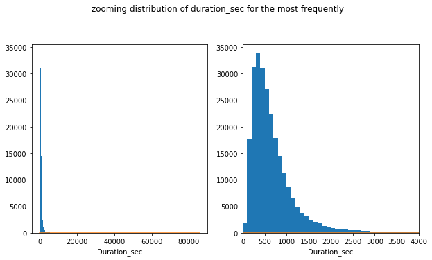

```python
plt.figure(figsize = [10, 5])

# histogram on left: full data
plt.subplot(1, 2, 1)
bin_edges = np.arange(0,bike_df['duration_sec'].max()+1,100)
plt.hist(data = bike_df, x = 'duration_sec', bins = bin_edges)
sb.distplot(bike_df['duration_sec'],bins=bin_edges,kde=True,hist_kws={'alpha':0.75})
plt.xlabel('Duration_sec');

# histogram on right: focus in on bulk of data < 35
plt.subplot(1, 2, 2)
bin_edges = np.arange(0,bike_df['duration_sec'].max()+1,100)
plt.hist(data = bike_df, x = 'duration_sec', bins = bin_edges)
plt.xlim(0, 4000)
sb.distplot(bike_df['duration_sec'],bins=bin_edges,kde=True,hist_kws={'alpha':0.75})
plt.suptitle("zooming distribution of duration_sec for the most frequently ", y = 1.04);
plt.xlabel('Duration_sec');
```

**from monday to friday is the highest number because all this days of work but sat and sun the days off for employee and the highest one is friday**

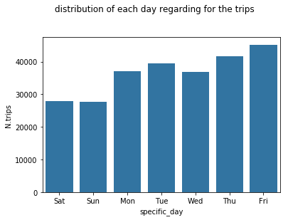

```python
level_order=['Sat','Sun','Mon','Tue','Wed','Thu','Fri']
ordered_bike=pd.api.types.CategoricalDtype(ordered=True,categories=level_order)
bike_df['specific_day']=bike_df['specific_day'].astype(ordered_bike)
base_color=sb.color_palette()[0]
sb.countplot(data=bike_df,x='specific_day',color=base_color);
plt.suptitle("distribution of each day regarding for the trips  ", y = 1.04);
plt.xlabel('specific_day');
plt.ylabel('N.trips');
```

**so show the text ratio of the frequency of the day per trip**

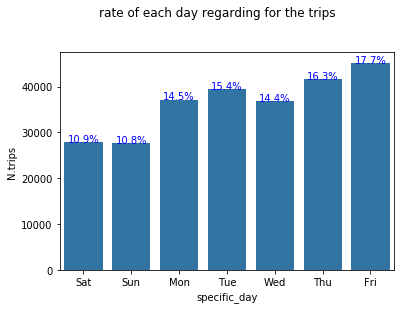

```python
base_color=sb.color_palette()[0]
sb.countplot(data=bike_df,x='specific_day',color=base_color);
n_points=bike_df.shape[0]
bike_counts=bike_df['specific_day'].value_counts()
locs,labels=plt.xticks()
for loc,label in zip(locs,labels):
    count=bike_counts[label.get_text()]
    bike_string='{:0.1f}%'.format(100*count/n_points)
    plt.text(loc,count-8,bike_string,ha='center',color='b')
    plt.suptitle("rate of each day regarding for the trips  ", y = 1.04);
    plt.xlabel('specific_day');
    plt.ylabel('N.trips');
```

**The hourly distribution is bimodal, the system is used mainly around 8-9am and 5-6pm when people get to and gat back from work.**

- hourly usege of the bike sharing system to know what the specific time we need to know to puch more offer on it to make a good motovition

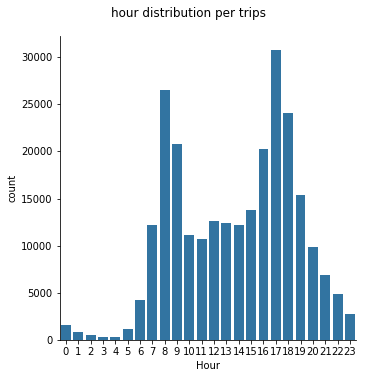

```python
sb.catplot(data=bike_df, x='hour', kind='count', color = base_color);
plt.suptitle("hour distribution per trips ", y = 1.04);
plt.xlabel('Hour');
```

below the same above but appear only area under curve

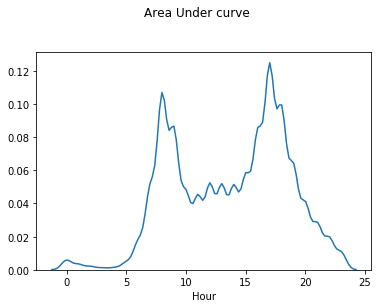

```python
bin_edges = np.arange(0,bike_df['hour'].max()+1,100)
sb.distplot(bike_df['hour'],bins=bin_edges,kde=True,hist_kws={'alpha':0.75})
plt.suptitle("Area Under curve ", y = 1.04);
plt.xlabel('Hour');
```

**regarding for this figure we can see subscriber is higher higher than customer that prove most of trips depend on the biker how payed to subscribe who is prove most of revenue effects by number of subscribers as we see above**

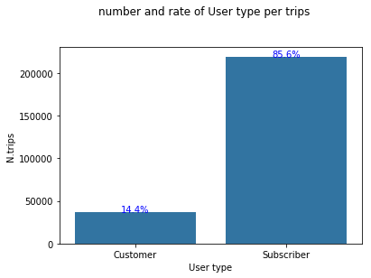

```python
base_color=sb.color_palette()[0]
sb.countplot(data=bike_df,x='user_type',color=base_color);
bike_counts=bike_df['user_type'].value_counts()
locs,labels=plt.xticks()
for loc,label in zip(locs,labels):
    count=bike_counts[label.get_text()]
    bike_string='{:0.1f}%'.format(100*count/n_points)
    plt.text(loc,count-8,bike_string,ha='center',color='b')
    plt.suptitle("number and rate of User type per trips ", y = 1.04);
    plt.xlabel('User type');
    plt.ylabel('N.trips')
```

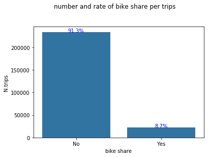

```python
base_color=sb.color_palette()[0]
sb.countplot(data=bike_df,x='bike_share_for_all_trip',color=base_color);
bike_counts=bike_df['bike_share_for_all_trip'].value_counts()
locs,labels=plt.xticks()
for loc,label in zip(locs,labels):
    count=bike_counts[label.get_text()]
    bike_string='{:0.1f}%'.format(100*count/n_points)
    plt.text(loc,count-8,bike_string,ha='center',color='b')
    plt.suptitle("number and rate of bike share per trips ", y = 1.04);
    plt.xlabel('bike share');
    plt.ylabel('N.trips')
```

# Bivariate Exploration

Bivariate visualizations are those that involve two variables we use bivariate visualizations to look at relationships when we change the level or value

| N | Type-1 | Type-2 | relationshipstype |
| --- | --- | --- | --- |
| 1 | quantitative | quantitative | Scatter plots |
| 2 | quantitative | Qualitative | Violin plots |
| 3 | Qualitative | Qualitative | Clustered bar charts |

**AS We see user type per hour trip there are most time between 600-1400 sec on the customer and the subscriber between (200-800) SO THE CUSTOMER trips make trips long time than the subscriber**

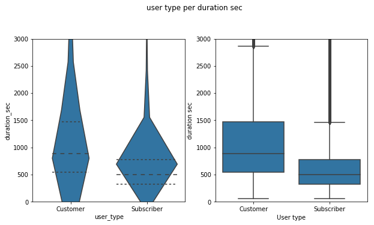

```python
plt.figure(figsize = [10, 5])
base_color = sb.color_palette()[0]
# left plot: violin plot
plt.subplot(1, 2, 1)
plt.ylim(0, 3000)
ax1 = sb.violinplot(data =  bike_df, x = 'user_type', y = 'duration_sec', color = base_color,inner = 'quartile')
# right plot: box plot
plt.subplot(1, 2, 2)
sb.boxplot(data =  bike_df, x = 'user_type', y = 'duration_sec', color = base_color)
plt.ylim(ax1.get_ylim())
plt.suptitle("user type per duration sec", y = 1.04);
plt.xlabel('User type');
plt.ylabel('duration sec')
```

**the customer has more trips on the saturday and sunday and for the subscriber we see all days high rate exept the vacation day because all subscriber are employees so they work all days exept the vacation days**

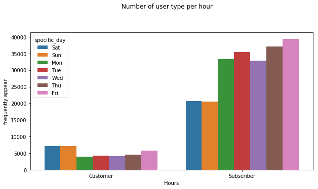

```python
plt.figure(figsize = [10, 5])
sb.countplot(data = bike_df, x = 'user_type', hue = 'specific_day');
plt.suptitle("Number of user type per hour", y = 1.04);
plt.xlabel('Hours');
plt.ylabel('frequently appear')
```

8 am and 5 pm is a higher time appear because this date for depature aand return from works and also the time of early after 6 am is rar to find ant trips

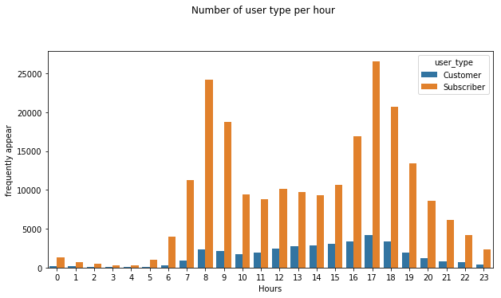

```python
plt.figure(figsize = [10, 5])
sb.countplot(data = bike_df, x = 'hour', hue = 'user_type');
plt.suptitle("Number of user type per hour", y = 1.04);
plt.xlabel('Hours');
plt.ylabel('frequently appear')
```

**big gab between bike_share_for_all_trip approved and not approved**

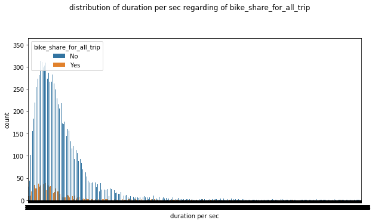

```python
plt.figure(figsize = [10, 5])
sb.countplot(data = bike_df, x = 'duration_sec', hue = 'bike_share_for_all_trip');
plt.suptitle("distribution of duration per sec regarding of bike_share_for_all_trip", y = 1.04);
plt.xlabel('duration per sec');
```

**any type of user as customer not has any bike_share_for_all_trip because so that is logic case how customer deserve bike_share_for_all_trip so we found the some subscribers deserve that and also that is logic because this type of userه is Permanent and paid monthly subscription**

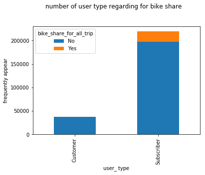

```python
bike_df.groupby(['user_type','bike_share_for_all_trip']).size().unstack().plot(kind='bar',stacked=True)

plt.suptitle("number of user type regarding for bike share", y = 1.04);
plt.xlabel('user_ type');
plt.ylabel('frequently appear');
```

**the figure show the number of trips per day regarding the user_type so we see days dows is days appear on vacation day (sat-sun days)also we see the number of subscriber higher number per day**

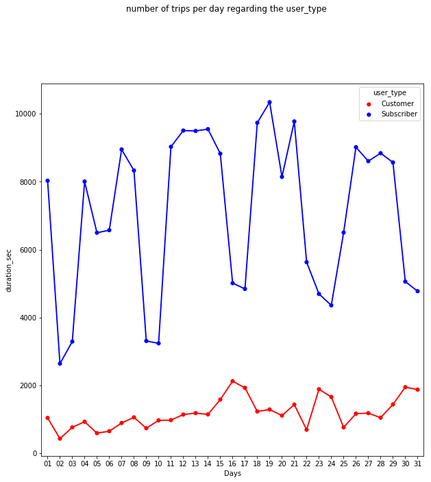

```python
usertype_count= bike_df.groupby(["day", "user_type"]).size().reset_index()
plt.figure(figsize=(10,10))
colors = {'Subscriber':'blue', 'Customer':'red'}
sb.pointplot(x='day', y=0, hue='user_type', palette=colors, scale=.7, data=usertype_count);
plt.suptitle("number of trips per day regarding the user_type", y = 1.04);
plt.xlabel('Days')
plt.ylabel('duration_sec')
```

# Multivariate Exploration

**number of bike share on the time duration per hour this appear more number not have bike share and also more duration time take the trip**

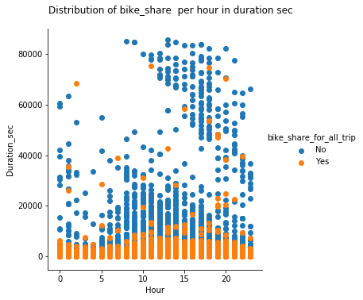

```python
plt.figure(figsize = [10, 5]);
g = sb.FacetGrid(data = bike_df, hue = 'bike_share_for_all_trip', size = 5);
g.map(plt.scatter, 'hour', 'duration_sec');
g.add_legend();

plt.suptitle("Distribution of bike_share  per hour in duration sec", y = 1.04);
plt.xlabel('Hour');
plt.ylabel('Duration_sec');
```

### Polishing Plots

**regarding for the figure on saturday and sundy is the high time duration because this employee vacation because remider the week normal checivement like goto work from monday to friday it the same rate although the customer make long trips**

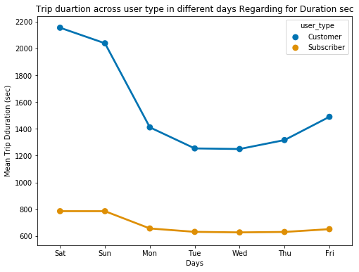

```python
fig = plt.figure(figsize = [8,6])
sb.pointplot(data = bike_df, x = 'specific_day', y = 'duration_sec', hue = 'user_type', palette = 'colorblind', ci=None)
plt.title('Trip duartion across user type in different days Regarding for Duration sec')
plt.ylabel('Mean Trip Dduration (sec)')
plt.xlabel('Days')
plt.show();
```

### below i will show the relationship between my interested three features

- bike_share_for_all_trip
- duration_sec
- user_type

**and i will show that by three ways**

- pointplot
- barplot

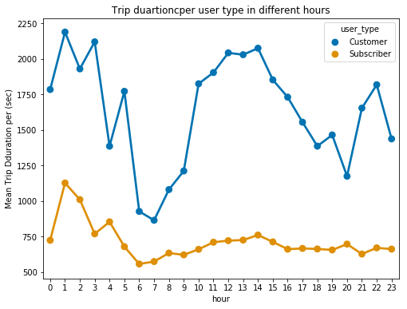

```python
fig = plt.figure(figsize = [8,6])
sb.pointplot(data = bike_df, x = 'hour', y = 'duration_sec', hue = 'user_type', palette = 'colorblind', ci=None)
plt.title('Trip duartioncper user type in different hours')
plt.ylabel('Mean Trip Dduration per (sec)')
plt.xlabel('hour')
plt.show();
```

**regarding for the figure we see no bike shae with customer and that is logic**

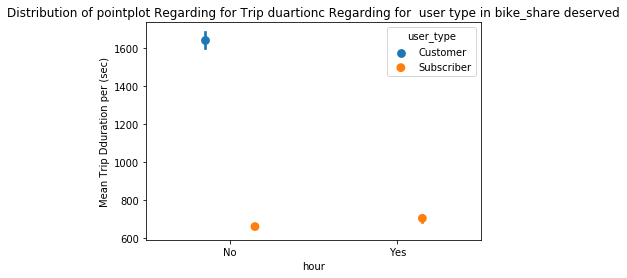

```python
ax = sb.pointplot(data = bike_df, x = 'bike_share_for_all_trip', y = 'duration_sec', hue = 'user_type',
dodge = 0.3, linestyles = "")
plt.title('Distribution of pointplot Regarding for Trip duartionc Regarding for  user type in bike_share deserved')
plt.ylabel('Mean Trip Dduration per (sec)')
plt.xlabel('hour')
plt.show();
```

**all customer not have any bike share for all trips but subscriber deserve that but not all of them**

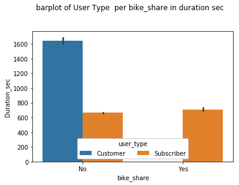

```python
ax = sb.barplot(data = bike_df, x = 'bike_share_for_all_trip', y = 'duration_sec', hue = 'user_type');
ax.legend(loc = 8, ncol = 3, framealpha = 1, title = 'user_type')
plt.suptitle("barplot of User Type  per bike_share in duration sec", y = 1.04);
plt.xlabel('bike_share');
plt.ylabel('Duration_sec');
```

**the heatmap it apper the 705.914 sec(11.7 minute) number of subscriber has bike share for all trip so most of subscriber not take long trip either has bike share or not**

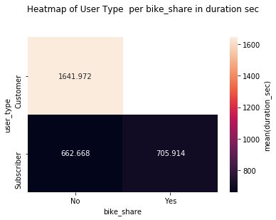

```python
bike_means = bike_df.groupby(['bike_share_for_all_trip', 'user_type']).mean()['duration_sec']
bike_means = bike_means.reset_index(name = 'num_var2_avg')
bike_means = bike_means.pivot(index = 'user_type', columns = 'bike_share_for_all_trip',
                            values = 'num_var2_avg')
sb.heatmap(bike_means, annot = True, fmt = '.3f',cbar_kws = {'label' : 'mean(duration_sec)'});
plt.suptitle("Heatmap of User Type  per bike_share in duration sec", y = 1.04);
plt.xlabel('bike_share');
```